# St Augustine st John

```r
final_homeless <- read_rds("final_homeless.rds")
```

##CAVEATS

- Sean’s approach so far is once homeless, always homeless, hence we add people, who’ve we’ve listed homeless once to the homeless data even if during appartment time
- Same approach goes to NA-s

##MOST COMMON CHARGES

We use initial statute, as this is the charge which is present the most

```r
final_homeless %>%
  select(full_name, case_id, initial_statute) %>%
  unique() %>%
  group_by(initial_statute) %>%
  count() %>%
  datatable()
```

|  | initial_statute | n |
| --- | --- | --- |
| 1 | 13-4 | 6 |
| 2 | 18-56 | 3 |
| 3 | 18-8 | 76 |
| 4 | 18-8 14 | 1 |
| 5 | 18-8 a2d | 4 |
| 6 | 19-23 2 | 1 |
| 7 | 2-323 | 5 |
| 8 | 2006-58(1) | 1 |
| 9 | 2007-19,3.01 | 10 |
| 10 | 2007-19,3.01(sab) | 1 |

[output cut: 378 more lines]

```r
final_homeless %>%
  group_by(court_type) %>%
  count() %>%
  arrange(desc(n)) %>%
  datatable()
```

|  | court_type | n |
| --- | --- | --- |
| 1 | misdemeanor | 1740 |
| 2 | criminal felony | 1342 |
| 3 | municipal ordinance | 685 |
| 4 | civil traffic | 296 |
| 5 | criminal traffic | 214 |
| 6 | county ordinance | 23 |
| 7 | animal control | 10 |
| 8 | boating infractions | 7 |
| 9 | parking | 6 |
| 10 | non-criminal infraction | 2 |

[output cut: 1 more lines]

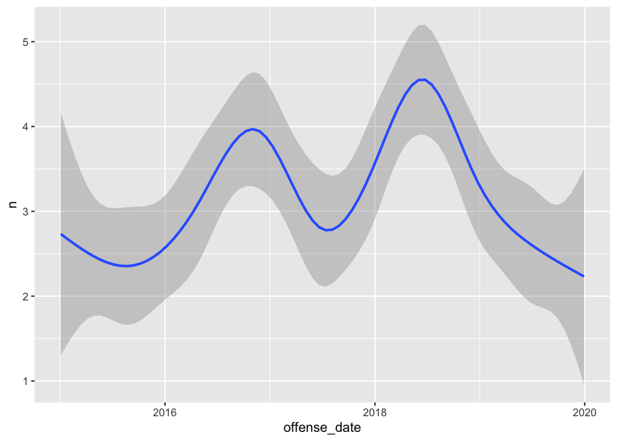

```r
final_homeless %>%
  filter(offense_date > "2014-12-31") %>%
  group_by(offense_date, case_number, full_name) %>%
  group_by(offense_date) %>%
  count() %>%
  ggplot()+
  geom_smooth(mapping = aes(offense_date, n))
```

##LAWS

TO DO

1. check people with 2970 Cabbage Road adresses whether they’re homeless, trespassing charges might refer to that
2. get a list of homeless centers, charity places, churches and join them against the addresses in the data – DONE

CAVEATS

1. For now, we’ve left people in the homeless addresses subset who have police dep address, as most of who have been charged with the most common charge – drinking in public – have also been charged with tresspassing, what is more, a lot of the top charges among these people refer to homeless as well,

### State laws that we associate with criminalizing homelessness

| State Law | Unconstitutional? | Description |
| --- | --- | --- |
| [316.130](http://www.leg.state.fl.us/statutes/index.cfm?mode=View%20Statutes&SubMenu=1&App_mode=Display_Statute&Search_String=316.130&URL=0300-0399/0316/Sections/0316.130.html) | ? | A pedestrian shall obey the instructions of any official traffic control device specifically applicable to the pedestrian unless otherwise directed by a police officer |
| [316.2045](http://www.leg.state.fl.us/statutes/index.cfm?mode=View%20Statutes&SubMenu=1&App_mode=Display_Statute&Search_String=316.2045&URL=0300-0399/0316/Sections/0316.2045.html) | Yes | Obstruction of public streets, highways, and roads. |
| [810.08(2a)](http://www.leg.state.fl.us/statutes/index.cfm?App_mode=Display_Statute&URL=0800-0899/0810/Sections/0810.08.html) | ? | Misdemeanor trespass in structure or conveyance |
| [810.08(2b)](http://www.leg.state.fl.us/statutes/index.cfm?App_mode=Display_Statute&URL=0800-0899/0810/Sections/0810.08.html) | ? | Misdemeanor trespass in occupied structure |
| [810.09(2a)](http://www.leg.state.fl.us/statutes/index.cfm?App_mode=Display_Statute&URL=0800-0899/0810/Sections/0810.09.html) | ? | Misdemeanor trespass on property other than structure or conveyance |
| [810.09(2b)](http://www.leg.state.fl.us/statutes/index.cfm?App_mode=Display_Statute&URL=0800-0899/0810/Sections/0810.09.html) | ? | Misdemeanor trespass on curtilage (i.e. a yard or shed or some other structure near a building) |
| [810.09(2d)](http://www.leg.state.fl.us/statutes/index.cfm?App_mode=Display_Statute&URL=0800-0899/0810/Sections/0810.09.html) | ? | Third degree felony trespass on a construction site of a certain size |
| [810.097](http://www.leg.state.fl.us/statutes/index.cfm?App_mode=Display_Statute&URL=0800-0899/0810/Sections/0810.09.html) | ? | Tresspass from school property |
| [856.011](http://www.leg.state.fl.us/statutes/index.cfm?App_mode=Display_Statute&URL=0800-0899/0856/Sections/0856.011.html) | ? | Disorderly intoxication |

### St Augustine City laws that we associate with criminalizing homelessness

| City Law | Unconstitutional? | Description |
| --- | --- | --- |
| [4-5](https://library.municode.com/fl/st._augustine/codes/code_of_ordinances?nodeId=PTIICOOR_CH4ALBE_S4-5DRPU) | ? | Public drinking |
| [13-4](https://library.municode.com/fl/st._augustine/codes/code_of_ordinances?nodeId=PTIICOOR_CH13TE_ARTICORI-W_S13-4REPLMACOFAPURI-W) | ? | Sleeping in public |
| [18-8](https://library.municode.com/fl/st._augustine/codes/code_of_ordinances?nodeId=PTIICOOR_CH18MIPROF) | ? | Panhandling |
| [22-12](https://library.municode.com/fl/st._augustine/codes/code_of_ordinances?nodeId=PTIICOOR_CH22STSIPAMIPUPL_ARTIINGE_S22-12SLCAHALEHUWAPUPLPR) | ? | Sleep/camp/habitation or leave human waste public |
| [18-56](https://library.municode.com/fl/st._augustine/codes/code_of_ordinances?nodeId=PTIICOOR_CH18MIPROF_ARTIIIOFINPUPEOR_S18-56WIOBPUWAPA) | ? | Wilful obstruction of public ways/passages |
| [24-14](https://library.municode.com/fl/st._augustine/codes/code_of_ordinances?nodeId=PTIICOOR_CH24TR_ARTIINGE_S24-14PRSASOTRLA) | ? | Prohibiting sales and solicitations in traffic lanes. |
| [99-50] | ? | Drinking in public |
| [91-11 ] | ? | Drinking in public |

#watch disordelry conduct separately